# Risk Factor Analysis

## Outcome Variable

**Outcome Variable:** haz

## Predictor Variables

**Intervention Variable:** mage

**Adjustment Set:**

unadjusted

## Stratifying Variables

The analysis was stratified on these variable(s):

- agecat
- studyid
- country

## Data Summary

| agecat | studyid | country | mage | n_cell | n |
| --- | --- | --- | --- | --- | --- |
| Birth | CMC-V-BCS-2002 | INDIA | [20-30) | 79 | 92 |
| Birth | CMC-V-BCS-2002 | INDIA | <20 | 9 | 92 |
| Birth | CMC-V-BCS-2002 | INDIA | >=30 | 4 | 92 |
| Birth | COHORTS | GUATEMALA | [20-30) | 405 | 852 |
| Birth | COHORTS | GUATEMALA | <20 | 121 | 852 |
| Birth | COHORTS | GUATEMALA | >=30 | 326 | 852 |
| Birth | COHORTS | INDIA | [20-30) | 3180 | 4715 |
| Birth | COHORTS | INDIA | <20 | 368 | 4715 |
| Birth | COHORTS | INDIA | >=30 | 1167 | 4715 |
| Birth | COHORTS | PHILIPPINES | [20-30) | 1821 | 3050 |
| Birth | COHORTS | PHILIPPINES | <20 | 378 | 3050 |
| Birth | COHORTS | PHILIPPINES | >=30 | 851 | 3050 |
| Birth | EE | PAKISTAN | [20-30) | 94 | 239 |
| Birth | EE | PAKISTAN | <20 | 1 | 239 |
| Birth | EE | PAKISTAN | >=30 | 144 | 239 |
| Birth | GMS-Nepal | NEPAL | [20-30) | 446 | 696 |
| Birth | GMS-Nepal | NEPAL | <20 | 149 | 696 |
| Birth | GMS-Nepal | NEPAL | >=30 | 101 | 696 |
| Birth | IRC | INDIA | [20-30) | 325 | 388 |
| Birth | IRC | INDIA | <20 | 35 | 388 |
| Birth | IRC | INDIA | >=30 | 28 | 388 |
| Birth | Keneba | GAMBIA | [20-30) | 705 | 1543 |
| Birth | Keneba | GAMBIA | <20 | 238 | 1543 |
| Birth | Keneba | GAMBIA | >=30 | 600 | 1543 |
| Birth | MAL-ED | BANGLADESH | [20-30) | 160 | 231 |
| Birth | MAL-ED | BANGLADESH | <20 | 30 | 231 |
| Birth | MAL-ED | BANGLADESH | >=30 | 41 | 231 |
| Birth | MAL-ED | BRAZIL | [20-30) | 41 | 65 |
| Birth | MAL-ED | BRAZIL | <20 | 8 | 65 |
| Birth | MAL-ED | BRAZIL | >=30 | 16 | 65 |

[output cut: 174 more lines]

The following strata were considered:

- agecat: 24 months, studyid: CMC-V-BCS-2002, country: INDIA
- agecat: 24 months, studyid: COHORTS, country: GUATEMALA
- agecat: 24 months, studyid: COHORTS, country: INDIA
- agecat: 24 months, studyid: COHORTS, country: PHILIPPINES
- agecat: 24 months, studyid: EE, country: PAKISTAN
- agecat: 24 months, studyid: GMS-Nepal, country: NEPAL
- agecat: 24 months, studyid: IRC, country: INDIA
- agecat: 24 months, studyid: Keneba, country: GAMBIA
- agecat: 24 months, studyid: LCNI-5, country: MALAWI
- agecat: 24 months, studyid: MAL-ED, country: BANGLADESH
- agecat: 24 months, studyid: MAL-ED, country: BRAZIL
- agecat: 24 months, studyid: MAL-ED, country: INDIA
- agecat: 24 months, studyid: MAL-ED, country: NEPAL
- agecat: 24 months, studyid: MAL-ED, country: PERU
- agecat: 24 months, studyid: MAL-ED, country: SOUTH AFRICA
- agecat: 24 months, studyid: MAL-ED, country: TANZANIA, UNITED REPUBLIC OF
- agecat: 24 months, studyid: NIH-Birth, country: BANGLADESH
- agecat: 24 months, studyid: NIH-Crypto, country: BANGLADESH
- agecat: 24 months, studyid: PROBIT, country: BELARUS
- agecat: 24 months, studyid: PROVIDE, country: BANGLADESH
- agecat: 24 months, studyid: TanzaniaChild2, country: TANZANIA, UNITED REPUBLIC OF
- agecat: 24 months, studyid: ZVITAMBO, country: ZIMBABWE
- agecat: 6 months, studyid: CMC-V-BCS-2002, country: INDIA
- agecat: 6 months, studyid: COHORTS, country: GUATEMALA
- agecat: 6 months, studyid: COHORTS, country: INDIA
- agecat: 6 months, studyid: COHORTS, country: PHILIPPINES
- agecat: 6 months, studyid: EE, country: PAKISTAN
- agecat: 6 months, studyid: GMS-Nepal, country: NEPAL
- agecat: 6 months, studyid: Guatemala BSC, country: GUATEMALA
- agecat: 6 months, studyid: IRC, country: INDIA
- agecat: 6 months, studyid: Keneba, country: GAMBIA
- agecat: 6 months, studyid: LCNI-5, country: MALAWI
- agecat: 6 months, studyid: MAL-ED, country: BANGLADESH
- agecat: 6 months, studyid: MAL-ED, country: BRAZIL
- agecat: 6 months, studyid: MAL-ED, country: INDIA
- agecat: 6 months, studyid: MAL-ED, country: NEPAL
- agecat: 6 months, studyid: MAL-ED, country: PERU
- agecat: 6 months, studyid: MAL-ED, country: SOUTH AFRICA
- agecat: 6 months, studyid: MAL-ED, country: TANZANIA, UNITED REPUBLIC OF
- agecat: 6 months, studyid: NIH-Birth, country: BANGLADESH
- agecat: 6 months, studyid: NIH-Crypto, country: BANGLADESH
- agecat: 6 months, studyid: PROBIT, country: BELARUS
- agecat: 6 months, studyid: PROVIDE, country: BANGLADESH
- agecat: 6 months, studyid: SAS-CompFeed, country: INDIA
- agecat: 6 months, studyid: SAS-FoodSuppl, country: INDIA
- agecat: 6 months, studyid: TanzaniaChild2, country: TANZANIA, UNITED REPUBLIC OF
- agecat: 6 months, studyid: ZVITAMBO, country: ZIMBABWE
- agecat: Birth, studyid: CMC-V-BCS-2002, country: INDIA
- agecat: Birth, studyid: COHORTS, country: GUATEMALA
- agecat: Birth, studyid: COHORTS, country: INDIA
- agecat: Birth, studyid: COHORTS, country: PHILIPPINES
- agecat: Birth, studyid: EE, country: PAKISTAN
- agecat: Birth, studyid: GMS-Nepal, country: NEPAL
- agecat: Birth, studyid: IRC, country: INDIA
- agecat: Birth, studyid: Keneba, country: GAMBIA
- agecat: Birth, studyid: MAL-ED, country: BANGLADESH
- agecat: Birth, studyid: MAL-ED, country: BRAZIL
- agecat: Birth, studyid: MAL-ED, country: INDIA
- agecat: Birth, studyid: MAL-ED, country: NEPAL
- agecat: Birth, studyid: MAL-ED, country: PERU
- agecat: Birth, studyid: MAL-ED, country: SOUTH AFRICA
- agecat: Birth, studyid: MAL-ED, country: TANZANIA, UNITED REPUBLIC OF
- agecat: Birth, studyid: NIH-Birth, country: BANGLADESH
- agecat: Birth, studyid: NIH-Crypto, country: BANGLADESH
- agecat: Birth, studyid: PROBIT, country: BELARUS
- agecat: Birth, studyid: PROVIDE, country: BANGLADESH
- agecat: Birth, studyid: SAS-CompFeed, country: INDIA
- agecat: Birth, studyid: ZVITAMBO, country: ZIMBABWE

### Dropped Strata

Some strata were dropped due to rare outcomes:

- agecat: Birth, studyid: CMC-V-BCS-2002, country: INDIA
- agecat: Birth, studyid: EE, country: PAKISTAN
- agecat: Birth, studyid: MAL-ED, country: INDIA
- agecat: Birth, studyid: MAL-ED, country: NEPAL
- agecat: 6 months, studyid: EE, country: PAKISTAN
- agecat: 24 months, studyid: EE, country: PAKISTAN
- agecat: 24 months, studyid: MAL-ED, country: NEPAL
- agecat: 24 months, studyid: TanzaniaChild2, country: TANZANIA, UNITED REPUBLIC OF

## Methods Detail

We’re interested in the causal parameters $E[Y_a]$ for all values of $a \in \mathcal{A}$. These parameters represent the mean outcome if, possibly contrary to fact, we intervened to set all units to have $A=a$. Under the randomization and positivity assumptions, these are identified by the statistical parameters $\psi_a=E_W[E_{Y|A,W}(Y|A=a,W)]$. In addition, we’re interested in the mean of $Y$, $E[Y]$ under no intervention (the observed mean). We will estimate these parameters by using SuperLearner to fit the relevant likelihood factors – $E_{Y|A,W}(Y|A=a,W)$ and $p(A=a|W)$, and then updating our likelihood fit using a joint TMLE.

For unadjusted analyses ($W=\{\}$), initial likelihoods were estimated using Lrnr_glm to estimate the simple $E(Y|A)$ and Lrnr_mean to estimate $p(A)$. For adjusted analyses, a small library containing Lrnr_glmnet, Lrnr_xgboost, and Lrnr_mean was used.

Having estimated these parameters, we will then use the delta method to estimate relative risks and attributable risks relative to a prespecified baseline level of $A$.

# Results Detail

## Results Plots

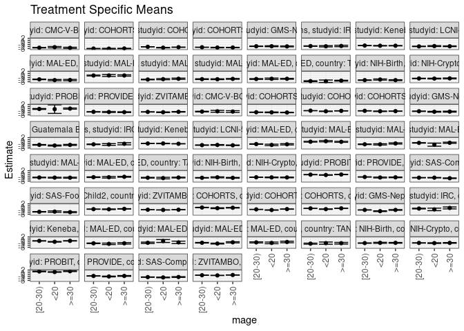

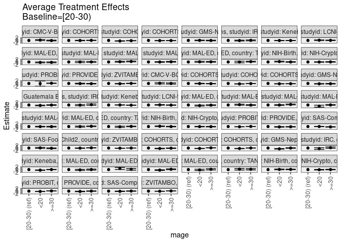

[figure not shown]

## Results Table

### Parameter: TSM

| agecat | studyid | country | intervention_level | baseline_level | estimate | ci_lower | ci_upper |
| --- | --- | --- | --- | --- | --- | --- | --- |
| Birth | COHORTS | GUATEMALA | [20-30) | NA | 0.2181728 | 0.0988231 | 0.3375226 |
| Birth | COHORTS | GUATEMALA | <20 | NA | -0.1109917 | -0.3142392 | 0.0922557 |
| Birth | COHORTS | GUATEMALA | >=30 | NA | 0.1092025 | -0.0324450 | 0.2508499 |
| Birth | COHORTS | INDIA | [20-30) | NA | -0.6880503 | -0.7284445 | -0.6476561 |
| Birth | COHORTS | INDIA | <20 | NA | -1.0003261 | -1.1096826 | -0.8909696 |
| Birth | COHORTS | INDIA | >=30 | NA | -0.5487061 | -0.6148683 | -0.4825439 |
| Birth | COHORTS | PHILIPPINES | [20-30) | NA | -0.2122845 | -0.2614820 | -0.1630869 |
| Birth | COHORTS | PHILIPPINES | <20 | NA | -0.5684921 | -0.6840624 | -0.4529218 |
| Birth | COHORTS | PHILIPPINES | >=30 | NA | -0.1858284 | -0.2606123 | -0.1110446 |
| Birth | GMS-Nepal | NEPAL | [20-30) | NA | -0.9572422 | -1.0523636 | -0.8621207 |
| Birth | GMS-Nepal | NEPAL | <20 | NA | -1.5544295 | -1.7330331 | -1.3758259 |
| Birth | GMS-Nepal | NEPAL | >=30 | NA | -0.9577228 | -1.1638509 | -0.7515946 |
| Birth | IRC | INDIA | [20-30) | NA | -0.2944615 | -0.4694031 | -0.1195200 |
| Birth | IRC | INDIA | <20 | NA | -0.6917143 | -1.3023032 | -0.0811254 |
| Birth | IRC | INDIA | >=30 | NA | 0.0139286 | -0.4512765 | 0.4791336 |
| Birth | Keneba | GAMBIA | [20-30) | NA | 0.0920000 | -0.0006387 | 0.1846387 |
| Birth | Keneba | GAMBIA | <20 | NA | -0.3447479 | -0.5017036 | -0.1877922 |
| Birth | Keneba | GAMBIA | >=30 | NA | 0.1078667 | 0.0047318 | 0.2110016 |
| Birth | MAL-ED | BANGLADESH | [20-30) | NA | -1.0886250 | -1.2466046 | -0.9306454 |
| Birth | MAL-ED | BANGLADESH | <20 | NA | -1.3273333 | -1.6755097 | -0.9791570 |
| Birth | MAL-ED | BANGLADESH | >=30 | NA | -1.0800000 | -1.4340222 | -0.7259778 |
| Birth | MAL-ED | BRAZIL | [20-30) | NA | -0.8314634 | -1.1601853 | -0.5027415 |
| Birth | MAL-ED | BRAZIL | <20 | NA | 0.0325000 | -0.6736983 | 0.7386983 |
| Birth | MAL-ED | BRAZIL | >=30 | NA | -0.6318750 | -1.2213825 | -0.0423675 |
| Birth | MAL-ED | PERU | [20-30) | NA | -0.8216667 | -0.9751882 | -0.6681451 |
| Birth | MAL-ED | PERU | <20 | NA | -1.2162121 | -1.4244256 | -1.0079986 |
| Birth | MAL-ED | PERU | >=30 | NA | -0.5990566 | -0.8696160 | -0.3284972 |
| Birth | MAL-ED | SOUTH AFRICA | [20-30) | NA | -0.6367164 | -0.9032080 | -0.3702248 |
| Birth | MAL-ED | SOUTH AFRICA | <20 | NA | -0.8869565 | -1.2893537 | -0.4845594 |
| Birth | MAL-ED | SOUTH AFRICA | >=30 | NA | -0.4436364 | -0.8150229 | -0.0722498 |

[output cut: 150 more lines]

### Parameter: E(Y)

| agecat | studyid | country | intervention_level | baseline_level | estimate | ci_lower | ci_upper |
| --- | --- | --- | --- | --- | --- | --- | --- |
| Birth | COHORTS | GUATEMALA | NA | NA | 0.1297300 | 0.0458017 | 0.2136584 |
| Birth | COHORTS | INDIA | NA | NA | -0.6779343 | -0.7109987 | -0.6448698 |
| Birth | COHORTS | PHILIPPINES | NA | NA | -0.2490492 | -0.2880580 | -0.2100404 |
| Birth | GMS-Nepal | NEPAL | NA | NA | -1.0851580 | -1.1651811 | -1.0051350 |
| Birth | IRC | INDIA | NA | NA | -0.3080412 | -0.4687931 | -0.1472894 |
| Birth | Keneba | GAMBIA | NA | NA | 0.0308036 | -0.0328378 | 0.0944451 |
| Birth | MAL-ED | BANGLADESH | NA | NA | -1.1180952 | -1.2525408 | -0.9836496 |
| Birth | MAL-ED | BRAZIL | NA | NA | -0.6760000 | -0.9521457 | -0.3998543 |
| Birth | MAL-ED | PERU | NA | NA | -0.8827897 | -1.0001058 | -0.7654736 |
| Birth | MAL-ED | SOUTH AFRICA | NA | NA | -0.6317073 | -0.8249555 | -0.4384591 |
| Birth | MAL-ED | TANZANIA, UNITED REPUBLIC OF | NA | NA | -1.1556000 | -1.3655361 | -0.9456639 |
| Birth | NIH-Birth | BANGLADESH | NA | NA | -0.9312706 | -1.0202524 | -0.8422889 |
| Birth | NIH-Crypto | BANGLADESH | NA | NA | -0.9094945 | -0.9809370 | -0.8380521 |
| Birth | PROBIT | BELARUS | NA | NA | 1.3114417 | 1.1524752 | 1.4704082 |
| Birth | PROVIDE | BANGLADESH | NA | NA | -0.8851020 | -0.9601332 | -0.8100709 |
| Birth | SAS-CompFeed | INDIA | NA | NA | -1.4314217 | -1.5099245 | -1.3529189 |
| Birth | ZVITAMBO | ZIMBABWE | NA | NA | -0.4999118 | -0.5204765 | -0.4793472 |
| 6 months | CMC-V-BCS-2002 | INDIA | NA | NA | -1.4234508 | -1.5645974 | -1.2823042 |
| 6 months | COHORTS | GUATEMALA | NA | NA | -1.8157336 | -1.8837688 | -1.7476985 |
| 6 months | COHORTS | INDIA | NA | NA | -1.0441293 | -1.0769738 | -1.0112848 |
| 6 months | COHORTS | PHILIPPINES | NA | NA | -1.1405724 | -1.1824954 | -1.0986493 |
| 6 months | GMS-Nepal | NEPAL | NA | NA | -1.3508392 | -1.4290633 | -1.2726152 |
| 6 months | Guatemala BSC | GUATEMALA | NA | NA | -1.5617391 | -1.6780690 | -1.4454093 |
| 6 months | IRC | INDIA | NA | NA | -1.2344062 | -1.3658524 | -1.1029600 |
| 6 months | Keneba | GAMBIA | NA | NA | -0.9040346 | -0.9513522 | -0.8567171 |
| 6 months | LCNI-5 | MALAWI | NA | NA | -1.6498804 | -1.7271669 | -1.5725940 |
| 6 months | MAL-ED | BANGLADESH | NA | NA | -1.2049931 | -1.3222136 | -1.0877726 |
| 6 months | MAL-ED | BRAZIL | NA | NA | 0.0475758 | -0.0963508 | 0.1915023 |
| 6 months | MAL-ED | INDIA | NA | NA | -1.2016239 | -1.3201698 | -1.0830780 |
| 6 months | MAL-ED | NEPAL | NA | NA | -0.5615819 | -0.6741832 | -0.4489807 |
| 6 months | MAL-ED | PERU | NA | NA | -1.3236661 | -1.4316775 | -1.2156546 |
| 6 months | MAL-ED | SOUTH AFRICA | NA | NA | -1.0633202 | -1.1909180 | -0.9357224 |
| 6 months | MAL-ED | TANZANIA, UNITED REPUBLIC OF | NA | NA | -1.3687449 | -1.4907629 | -1.2467270 |
| 6 months | NIH-Birth | BANGLADESH | NA | NA | -1.4062134 | -1.4951703 | -1.3172565 |
| 6 months | NIH-Crypto | BANGLADESH | NA | NA | -1.1986783 | -1.2700937 | -1.1272630 |
| 6 months | PROBIT | BELARUS | NA | NA | 0.0980074 | 0.0062724 | 0.1897424 |
| 6 months | PROVIDE | BANGLADESH | NA | NA | -1.0916915 | -1.1661176 | -1.0172654 |
| 6 months | SAS-CompFeed | INDIA | NA | NA | -1.4018563 | -1.4810585 | -1.3226541 |
| 6 months | SAS-FoodSuppl | INDIA | NA | NA | -1.8986842 | -2.0118892 | -1.7854792 |
| 6 months | TanzaniaChild2 | TANZANIA, UNITED REPUBLIC OF | NA | NA | -0.5410317 | -0.5901099 | -0.4919536 |
| 6 months | ZVITAMBO | ZIMBABWE | NA | NA | -0.8672235 | -0.8928135 | -0.8416336 |
| 24 months | CMC-V-BCS-2002 | INDIA | NA | NA | -2.5588679 | -2.6583730 | -2.4593629 |
| 24 months | COHORTS | GUATEMALA | NA | NA | -2.9905921 | -3.0548289 | -2.9263553 |
| 24 months | COHORTS | INDIA | NA | NA | -2.2182259 | -2.2576094 | -2.1788424 |
| 24 months | COHORTS | PHILIPPINES | NA | NA | -2.4141145 | -2.4590818 | -2.3691473 |
| 24 months | GMS-Nepal | NEPAL | NA | NA | -1.8874180 | -1.9728588 | -1.8019773 |
| 24 months | IRC | INDIA | NA | NA | -1.7987775 | -1.8923914 | -1.7051636 |
| 24 months | Keneba | GAMBIA | NA | NA | -1.5798251 | -1.6298520 | -1.5297981 |
| 24 months | LCNI-5 | MALAWI | NA | NA | -1.8966105 | -1.9881282 | -1.8050928 |
| 24 months | MAL-ED | BANGLADESH | NA | NA | -1.9783962 | -2.1050210 | -1.8517715 |
| 24 months | MAL-ED | BRAZIL | NA | NA | 0.0061144 | -0.1625850 | 0.1748138 |
| 24 months | MAL-ED | INDIA | NA | NA | -1.8901556 | -2.0155338 | -1.7647773 |
| 24 months | MAL-ED | PERU | NA | NA | -1.7524710 | -1.8736426 | -1.6312994 |
| 24 months | MAL-ED | SOUTH AFRICA | NA | NA | -1.6450595 | -1.7797240 | -1.5103950 |
| 24 months | MAL-ED | TANZANIA, UNITED REPUBLIC OF | NA | NA | -2.6455607 | -2.7807256 | -2.5103959 |
| 24 months | NIH-Birth | BANGLADESH | NA | NA | -2.2200371 | -2.3231580 | -2.1169161 |
| 24 months | NIH-Crypto | BANGLADESH | NA | NA | -1.4412646 | -1.5249156 | -1.3576135 |
| 24 months | PROBIT | BELARUS | NA | NA | -0.1442891 | -0.4253755 | 0.1367972 |
| 24 months | PROVIDE | BANGLADESH | NA | NA | -1.6024221 | -1.6857420 | -1.5191023 |
| 24 months | ZVITAMBO | ZIMBABWE | NA | NA | -1.6052656 | -1.6623196 | -1.5482116 |

### Parameter: ATE

| agecat | studyid | country | intervention_level | baseline_level | estimate | ci_lower | ci_upper |
| --- | --- | --- | --- | --- | --- | --- | --- |
| Birth | COHORTS | GUATEMALA | [20-30) | [20-30) | 0.0000000 | 0.0000000 | 0.0000000 |
| Birth | COHORTS | GUATEMALA | <20 | [20-30) | -0.3291646 | -0.5648633 | -0.0934659 |
| Birth | COHORTS | GUATEMALA | >=30 | [20-30) | -0.1089704 | -0.2941956 | 0.0762548 |
| Birth | COHORTS | INDIA | [20-30) | [20-30) | 0.0000000 | 0.0000000 | 0.0000000 |
| Birth | COHORTS | INDIA | <20 | [20-30) | -0.3122758 | -0.4288542 | -0.1956973 |
| Birth | COHORTS | INDIA | >=30 | [20-30) | 0.1393442 | 0.0618257 | 0.2168628 |
| Birth | COHORTS | PHILIPPINES | [20-30) | [20-30) | 0.0000000 | 0.0000000 | 0.0000000 |
| Birth | COHORTS | PHILIPPINES | <20 | [20-30) | -0.3562076 | -0.4818137 | -0.2306015 |
| Birth | COHORTS | PHILIPPINES | >=30 | [20-30) | 0.0264560 | -0.0630595 | 0.1159715 |
| Birth | GMS-Nepal | NEPAL | [20-30) | [20-30) | 0.0000000 | 0.0000000 | 0.0000000 |
| Birth | GMS-Nepal | NEPAL | <20 | [20-30) | -0.5971874 | -0.7995419 | -0.3948329 |
| Birth | GMS-Nepal | NEPAL | >=30 | [20-30) | -0.0004806 | -0.2274980 | 0.2265368 |
| Birth | IRC | INDIA | [20-30) | [20-30) | 0.0000000 | 0.0000000 | 0.0000000 |
| Birth | IRC | INDIA | <20 | [20-30) | -0.3972527 | -1.0324089 | 0.2379034 |
| Birth | IRC | INDIA | >=30 | [20-30) | 0.3083901 | -0.1886213 | 0.8054015 |
| Birth | Keneba | GAMBIA | [20-30) | [20-30) | 0.0000000 | 0.0000000 | 0.0000000 |
| Birth | Keneba | GAMBIA | <20 | [20-30) | -0.4367479 | -0.6190033 | -0.2544925 |
| Birth | Keneba | GAMBIA | >=30 | [20-30) | 0.0158667 | -0.1227650 | 0.1544983 |
| Birth | MAL-ED | BANGLADESH | [20-30) | [20-30) | 0.0000000 | 0.0000000 | 0.0000000 |
| Birth | MAL-ED | BANGLADESH | <20 | [20-30) | -0.2387083 | -0.6210489 | 0.1436323 |
| Birth | MAL-ED | BANGLADESH | >=30 | [20-30) | 0.0086250 | -0.3790466 | 0.3962966 |
| Birth | MAL-ED | BRAZIL | [20-30) | [20-30) | 0.0000000 | 0.0000000 | 0.0000000 |
| Birth | MAL-ED | BRAZIL | <20 | [20-30) | 0.8639634 | 0.0850064 | 1.6429205 |
| Birth | MAL-ED | BRAZIL | >=30 | [20-30) | 0.1995884 | -0.4753761 | 0.8745529 |
| Birth | MAL-ED | PERU | [20-30) | [20-30) | 0.0000000 | 0.0000000 | 0.0000000 |
| Birth | MAL-ED | PERU | <20 | [20-30) | -0.3945455 | -0.6532378 | -0.1358531 |
| Birth | MAL-ED | PERU | >=30 | [20-30) | 0.2226101 | -0.0884708 | 0.5336909 |
| Birth | MAL-ED | SOUTH AFRICA | [20-30) | [20-30) | 0.0000000 | 0.0000000 | 0.0000000 |
| Birth | MAL-ED | SOUTH AFRICA | <20 | [20-30) | -0.2502401 | -0.7328800 | 0.2323998 |
| Birth | MAL-ED | SOUTH AFRICA | >=30 | [20-30) | 0.1930801 | -0.2640258 | 0.6501859 |

[output cut: 150 more lines]

### Parameter: PAR

| agecat | studyid | country | intervention_level | baseline_level | estimate | ci_lower | ci_upper |
| --- | --- | --- | --- | --- | --- | --- | --- |
| Birth | COHORTS | GUATEMALA | [20-30) | NA | -0.0884428 | -0.1764550 | -0.0004305 |
| Birth | COHORTS | INDIA | [20-30) | NA | 0.0101161 | -0.0127747 | 0.0330068 |
| Birth | COHORTS | PHILIPPINES | [20-30) | NA | -0.0367647 | -0.0691976 | -0.0043318 |
| Birth | GMS-Nepal | NEPAL | [20-30) | NA | -0.1279159 | -0.1900098 | -0.0658220 |
| Birth | IRC | INDIA | [20-30) | NA | -0.0135797 | -0.0855186 | 0.0583592 |
| Birth | Keneba | GAMBIA | [20-30) | NA | -0.0611964 | -0.1304059 | 0.0080131 |
| Birth | MAL-ED | BANGLADESH | [20-30) | NA | -0.0294702 | -0.1214482 | 0.0625077 |
| Birth | MAL-ED | BRAZIL | [20-30) | NA | 0.1554634 | -0.0636144 | 0.3745412 |
| Birth | MAL-ED | PERU | [20-30) | NA | -0.0611230 | -0.1805753 | 0.0583292 |
| Birth | MAL-ED | SOUTH AFRICA | [20-30) | NA | 0.0050091 | -0.1710411 | 0.1810594 |
| Birth | MAL-ED | TANZANIA, UNITED REPUBLIC OF | [20-30) | NA | 0.0957889 | -0.0895533 | 0.2811310 |
| Birth | NIH-Birth | BANGLADESH | [20-30) | NA | 0.0386562 | -0.0214674 | 0.0987798 |
| Birth | NIH-Crypto | BANGLADESH | [20-30) | NA | -0.0136974 | -0.0658890 | 0.0384941 |
| Birth | PROBIT | BELARUS | [20-30) | NA | -0.0032902 | -0.0220858 | 0.0155053 |
| Birth | PROVIDE | BANGLADESH | [20-30) | NA | -0.0303851 | -0.0807566 | 0.0199865 |
| Birth | SAS-CompFeed | INDIA | [20-30) | NA | -0.0156505 | -0.0493415 | 0.0180406 |
| Birth | ZVITAMBO | ZIMBABWE | [20-30) | NA | 0.0031251 | -0.0114219 | 0.0176720 |
| 6 months | CMC-V-BCS-2002 | INDIA | [20-30) | NA | 0.0124195 | -0.0598970 | 0.0847361 |
| 6 months | COHORTS | GUATEMALA | [20-30) | NA | -0.0567336 | -0.1261799 | 0.0127127 |
| 6 months | COHORTS | INDIA | [20-30) | NA | -0.0434418 | -0.0659215 | -0.0209621 |
| 6 months | COHORTS | PHILIPPINES | [20-30) | NA | -0.0741139 | -0.1094376 | -0.0387903 |
| 6 months | GMS-Nepal | NEPAL | [20-30) | NA | -0.0719219 | -0.1315191 | -0.0123247 |
| 6 months | Guatemala BSC | GUATEMALA | [20-30) | NA | -0.0644877 | -0.1545897 | 0.0256144 |
| 6 months | IRC | INDIA | [20-30) | NA | 0.0110616 | -0.0454626 | 0.0675858 |
| 6 months | Keneba | GAMBIA | [20-30) | NA | -0.0464754 | -0.0961943 | 0.0032436 |
| 6 months | LCNI-5 | MALAWI | [20-30) | NA | -0.0095233 | -0.0799927 | 0.0609461 |
| 6 months | MAL-ED | BANGLADESH | [20-30) | NA | -0.0836901 | -0.1697608 | 0.0023807 |
| 6 months | MAL-ED | BRAZIL | [20-30) | NA | 0.0320158 | -0.0805535 | 0.1445850 |
| 6 months | MAL-ED | INDIA | [20-30) | NA | 0.0316349 | -0.0303339 | 0.0936038 |
| 6 months | MAL-ED | NEPAL | [20-30) | NA | -0.0089693 | -0.0756683 | 0.0577297 |
| 6 months | MAL-ED | PERU | [20-30) | NA | -0.0369136 | -0.1453213 | 0.0714941 |
| 6 months | MAL-ED | SOUTH AFRICA | [20-30) | NA | 0.0639538 | -0.0713592 | 0.1992668 |
| 6 months | MAL-ED | TANZANIA, UNITED REPUBLIC OF | [20-30) | NA | 0.0224530 | -0.0946649 | 0.1395709 |
| 6 months | NIH-Birth | BANGLADESH | [20-30) | NA | 0.0178529 | -0.0438292 | 0.0795350 |
| 6 months | NIH-Crypto | BANGLADESH | [20-30) | NA | -0.0261026 | -0.0793768 | 0.0271717 |
| 6 months | PROBIT | BELARUS | [20-30) | NA | -0.0066896 | -0.0214810 | 0.0081017 |
| 6 months | PROVIDE | BANGLADESH | [20-30) | NA | -0.0608621 | -0.1093982 | -0.0123260 |
| 6 months | SAS-CompFeed | INDIA | [20-30) | NA | -0.0282673 | -0.0455602 | -0.0109744 |
| 6 months | SAS-FoodSuppl | INDIA | [20-30) | NA | -0.0240865 | -0.1021286 | 0.0539556 |
| 6 months | TanzaniaChild2 | TANZANIA, UNITED REPUBLIC OF | [20-30) | NA | 0.0356862 | 0.0002043 | 0.0711680 |
| 6 months | ZVITAMBO | ZIMBABWE | [20-30) | NA | -0.0181907 | -0.0364144 | 0.0000330 |
| 24 months | CMC-V-BCS-2002 | INDIA | [20-30) | NA | 0.0137818 | -0.0363540 | 0.0639176 |
| 24 months | COHORTS | GUATEMALA | [20-30) | NA | 0.0077381 | -0.0570851 | 0.0725612 |
| 24 months | COHORTS | INDIA | [20-30) | NA | -0.0802803 | -0.1081206 | -0.0524400 |
| 24 months | COHORTS | PHILIPPINES | [20-30) | NA | -0.0491351 | -0.0861715 | -0.0120987 |
| 24 months | GMS-Nepal | NEPAL | [20-30) | NA | -0.0060658 | -0.0719429 | 0.0598112 |
| 24 months | IRC | INDIA | [20-30) | NA | -0.0051575 | -0.0452480 | 0.0349331 |
| 24 months | Keneba | GAMBIA | [20-30) | NA | -0.0452242 | -0.0991967 | 0.0087483 |
| 24 months | LCNI-5 | MALAWI | [20-30) | NA | 0.0419695 | -0.0448103 | 0.1287493 |
| 24 months | MAL-ED | BANGLADESH | [20-30) | NA | -0.1061360 | -0.1929749 | -0.0192970 |
| 24 months | MAL-ED | BRAZIL | [20-30) | NA | 0.0049216 | -0.1318186 | 0.1416618 |
| 24 months | MAL-ED | INDIA | [20-30) | NA | 0.0595828 | -0.0026246 | 0.1217902 |
| 24 months | MAL-ED | PERU | [20-30) | NA | 0.0229372 | -0.1020294 | 0.1479038 |
| 24 months | MAL-ED | SOUTH AFRICA | [20-30) | NA | 0.0593902 | -0.0902123 | 0.2089926 |
| 24 months | MAL-ED | TANZANIA, UNITED REPUBLIC OF | [20-30) | NA | 0.1023596 | -0.0247706 | 0.2294898 |
| 24 months | NIH-Birth | BANGLADESH | [20-30) | NA | 0.0308539 | -0.0390010 | 0.1007089 |
| 24 months | NIH-Crypto | BANGLADESH | [20-30) | NA | -0.0060550 | -0.0668211 | 0.0547111 |
| 24 months | PROBIT | BELARUS | [20-30) | NA | 0.0266061 | -0.1535541 | 0.2067663 |
| 24 months | PROVIDE | BANGLADESH | [20-30) | NA | -0.0353684 | -0.0895766 | 0.0188398 |
| 24 months | ZVITAMBO | ZIMBABWE | [20-30) | NA | -0.0126134 | -0.0526706 | 0.0274438 |